# ML Final Project

Andon Breitenfeld, Sarthak Dayal, Spencer Dwyer, Michael Golikov

```python
import numpy as np
import pandas as pd
from pandas import DataFrame
import scipy
import matplotlib.pyplot as plt
import seaborn as sns

from sklearn.model_selection import train_test_split, cross_val_score, KFold, RandomizedSearchCV
from sklearn.preprocessing import StandardScaler
from sklearn.decomposition import PCA
from sklearn.pipeline import Pipeline
from sklearn.impute import SimpleImputer
from sklearn.linear_model import LinearRegression
from sklearn.neural_network import MLPRegressor
from sklearn.ensemble import HistGradientBoostingRegressor
from sklearn.metrics import mean_squared_error, r2_score, root_mean_squared_error
from xgboost import XGBRegressor
from catboost import CatBoostRegressor

train_data = pd.read_csv("cattle_data_train.csv")
test_data = pd.read_csv("cattle_data_test.csv")
```

# Data Cleaning

## Breed

The most obvious data quality issue was the inconsistencies in the breed names (leading/trailing spaces or misspellings causing one breed to be erroneously split into multiple categories).

```python
def fix_breed(df: DataFrame):
    df["Breed"] = (
            df["Breed"]
            .str.strip()
            .str.title()
            .str.replace("Holstien", "Holstein")
        )

    return df
```

## Negative Values

We found that some rows had a negative value for the milk yield, which does not make sense. Ultimately, how we treated these values did not make any measurable difference, since there were so few of them. We left them in for our final model, though dropping the rows would have also been a good option, since we wouldn't have lost much data.

```python
print((train_data['Milk_Yield_L'] < 0).sum())
```

```
74
```

## Missing Values

There were a good number of missing values for feed quantity and housing score. We tried imputing and dropping the missing values for both the train and test sets. We found that the best performance was achieved by dropping the missing values from the training set and imputing them for the test set. We recognize that the best practice is usually to train the imputer on the train set and transform the test data using that, though since we had access to the complete test set, we imputed values based on the means for each feature in the test set itself. This way, any unique attributes of the test would be preserved in the imputed values.

```python
print(train_data.isna().sum())
```

```
Cattle_ID                      0
Breed                          0
Climate_Zone                   0
Management_System              0
Age_Months                     0
Weight_kg                      0
Parity                         0
Lactation_Stage                0
Days_in_Milk                   0
Feed_Type                      0
Feed_Quantity_kg           10481
Feeding_Frequency              0
Water_Intake_L                 0
Walking_Distance_km            0
Grazing_Duration_hrs           0
Rumination_Time_hrs            0
Resting_Hours                  0
Ambient_Temperature_C          0
Humidity_percent               0
Housing_Score               6279
FMD_Vaccine                    0
Brucellosis_Vaccine            0
HS_Vaccine                     0
BQ_Vaccine                     0
Anthrax_Vaccine                0
IBR_Vaccine                    0
BVD_Vaccine                    0
Rabies_Vaccine                 0
Previous_Week_Avg_Yield        0
Body_Condition_Score           0
Milking_Interval_hrs           0
Date                           0
Farm_ID                        0
Feed_Quantity_lb           10481
Mastitis                       0
Milk_Yield_L                   0
dtype: int64
```

```python
def handle_nans(X_train, y_train, X_test):
    imputer = SimpleImputer()
    X_test['Feed_Quantity_kg'] = imputer.fit_transform(X_test[['Feed_Quantity_kg']])[:, 0]

    X_all: DataFrame = X_train.join(y_train)
    X_all = X_all.dropna()
    X_train = X_all.drop(['Milk_Yield_L'], axis=1)
    y_train = X_all['Milk_Yield_L']

    return X_train, y_train, X_test
```

## Final Cleaning Code

This is the full cleaning process used by our final model.

```python
def clean_data(train_data, test_data):
    y_train = train_data['Milk_Yield_L']
    X_train = train_data.drop(['Milk_Yield_L'], axis=1)
    X_test = test_data

    X_train = fix_breed(X_train)
    X_test = fix_breed(X_test)

    X_train_cleaned, y_train_cleaned, X_test_cleaned = handle_nans(X_train, y_train, X_test)
    return X_train_cleaned, y_train_cleaned, X_test_cleaned

X_train_cleaned, y_train_cleaned, X_test_cleaned = clean_data(train_data, test_data)
```

# Data Exploration

This section focuses on understanding the dataset structure, identifying data quality issues, and analyzing relationships between features and the target variable.

## 1. Load and Initial Data Inspection

Load the dataset and examine its basic structure.

```python
pd.set_option("display.max_columns", 200)
```

```python
df = pd.read_csv('data/cattle_data_train.csv')
df.head()
```

|  | Cattle_ID | Breed | Climate_Zone | Management_System | Age_Months | Weight_kg | Parity | Lactation_Stage | Days_in_Milk | Feed_Type | Feed_Quantity_kg | Feeding_Frequency | Water_Intake_L | Walking_Distance_km | Grazing_Duration_hrs | Rumination_Time_hrs | Resting_Hours | Ambient_Temperature_C | Humidity_percent | Housing_Score | FMD_Vaccine | Brucellosis_Vaccine | HS_Vaccine | BQ_Vaccine | Anthrax_Vaccine | IBR_Vaccine | BVD_Vaccine | Rabies_Vaccine | Previous_Week_Avg_Yield | … |
| --- | --- | --- | --- | --- | --- | --- | --- | --- | --- | --- | --- | --- | --- | --- | --- | --- | --- | --- | --- | --- | --- | --- | --- | --- | --- | --- | --- | --- | --- | --- |
| 0 | CATTLE_133713 | Holstein | Tropical | Intensive | 114 | 544.8 | 4 | Mid | 62 | Concentrates | 16.363455 | 2 | 71.101024 | 4.77 | 7.8 | -2.269369 | 12.3 | 28.706090 | 70.6 | 0.871430 | 0 | 1 | 1 | 0 | 0 | 1 | 0 | 1 | 6.31 | … |
| 1 | CATTLE_027003 | Holstein | Arid | Mixed | 136 | 298.9 | 4 | Mid | 213 | Crop_Residues | NaN | 4 | 55.697328 | 5.99 | 7.4 | 8.973851 | 11.4 | 28.599741 | 57.5 | 0.825488 | 1 | 1 | 0 | 1 | 0 | 0 | 0 | 0 | 17.16 | … |
| 2 | CATTLE_122459 | Holstein | Tropical | Semi_Intensive | 64 | 336.6 | 4 | Late | 16 | Hay | 7.198607 | 2 | 65.576827 | 3.45 | 8.8 | -4.590550 | 8.6 | 12.520386 | 51.2 | 0.904957 | 0 | 0 | 1 | 1 | 0 | 1 | 1 | 0 | 4.07 | … |
| 3 | CATTLE_213419 | Jersey | Mediterranean | Intensive | 58 | 370.5 | 1 | Early | 339 | Crop_Residues | 18.694344 | 2 | 71.238287 | 5.95 | 6.5 | 1.792698 | 10.1 | 40.510261 | 57.9 | 0.324955 | 1 | 0 | 1 | 0 | 1 | 0 | 0 | 0 | 10.23 | … |
| 4 | CATTLE_106260 | Guernsey | Subtropical | Intensive | 84 | 641.5 | 6 | Early | 125 | Mixed_Feed | 14.779198 | 4 | 46.979548 | 5.39 | 6.4 | 12.621422 | 9.3 | -7.711288 | 73.2 | 0.871019 | 0 | 1 | 1 | 1 | 1 | 0 | 1 | 1 | 20.68 | … |

Check the dataset dimensions and column names.

```python
df.columns, df.shape
```

```
(Index(['Cattle_ID', 'Breed', 'Climate_Zone', 'Management_System', 'Age_Months',
        'Weight_kg', 'Parity', 'Lactation_Stage', 'Days_in_Milk', 'Feed_Type',
        'Feed_Quantity_kg', 'Feeding_Frequency', 'Water_Intake_L',
        'Walking_Distance_km', 'Grazing_Duration_hrs', 'Rumination_Time_hrs',
        'Resting_Hours', 'Ambient_Temperature_C', 'Humidity_percent',
        'Housing_Score', 'FMD_Vaccine', 'Brucellosis_Vaccine', 'HS_Vaccine',
        'BQ_Vaccine', 'Anthrax_Vaccine', 'IBR_Vaccine', 'BVD_Vaccine',
        'Rabies_Vaccine', 'Previous_Week_Avg_Yield', 'Body_Condition_Score',
        'Milking_Interval_hrs', 'Date', 'Farm_ID', 'Feed_Quantity_lb',
        'Mastitis', 'Milk_Yield_L'],
       dtype='object'),
 (210000, 36))
```

## 2. Categorical Variables Exploration

Examine the unique values in categorical columns. This helps identify:

- Data quality issues (typos, inconsistent formatting)
- Number of categories per variable
- Potential encoding strategies

**Key findings from the output:**

- **Breed**: Found data quality issues - typos ('Holstien' instead of 'Holstein') and whitespace issues (' Brown Swiss', 'Brown Swiss '). After cleaning, we have 4 breeds: Holstein, Jersey, Guernsey, and Brown Swiss.
- **Climate_Zone**: 6 distinct zones (Tropical, Arid, Mediterranean, Subtropical, Continental, Temperate)
- **Management_System**: 5 types (Intensive, Mixed, Semi_Intensive, Pastoral, Extensive)
- **Lactation_Stage**: 3 stages (Early, Mid, Late) - can be encoded as ordinal
- **Feed_Type**: 8 different feed types
- **Farm_ID**: 1000 unique farms (high cardinality categorical)

```python
print(df['Breed'].unique())
print(df['Climate_Zone'].unique())
print(df['Management_System'].unique())
print(df['Lactation_Stage'].unique())
print(df['Feed_Type'].unique())
print(len(df['Farm_ID'].unique()))

has_labels = ['Breed', 'Climate_Zone', 'Management_System', 'Lactation_Stage', 'Feed_Type', 'Farm_ID']

df['Breed'] = df['Breed'].str.strip()
df['Breed'] = df['Breed'].replace('Holstien', 'Holstein')
print("\nAfter cleaning:")
print(df['Breed'].unique())
```

```
['Holstein' 'Jersey' 'Guernsey' 'Brown Swiss' ' Brown Swiss' 'Holstien'
 'Brown Swiss ']
['Tropical' 'Arid' 'Mediterranean' 'Subtropical' 'Continental' 'Temperate']
['Intensive' 'Mixed' 'Semi_Intensive' 'Pastoral' 'Extensive']
['Mid' 'Late' 'Early']
['Concentrates' 'Crop_Residues' 'Hay' 'Mixed_Feed' 'Silage' 'Dry_Fodder'
 'Pasture_Grass' 'Green_Fodder']
1000

After cleaning:
['Holstein' 'Jersey' 'Guernsey' 'Brown Swiss']
```

## 3. Breed Analysis

Visualize the relationship between breed and milk yield. This helps understand if breed is a predictive feature.

**Insight**: The bar chart shows average milk yield by breed. While differences exist, they appear relatively small, suggesting breed may have limited predictive power on its own.

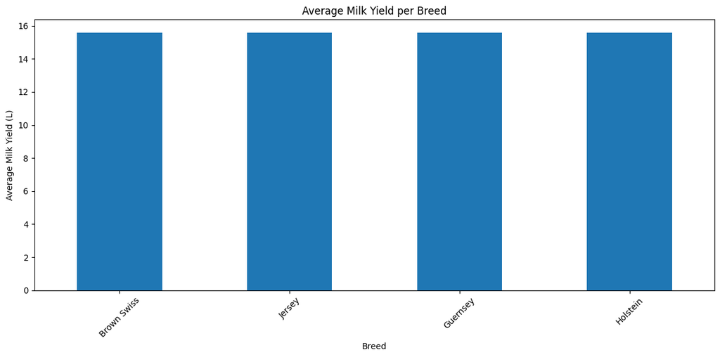

```python
breed_yield = df.groupby('Breed')['Milk_Yield_L'].mean().sort_values()

plt.figure(figsize=(12,6))
breed_yield.plot(kind='bar')

plt.xlabel('Breed')
plt.ylabel('Average Milk Yield (L)')
plt.title('Average Milk Yield per Breed')
plt.xticks(rotation=45)
plt.tight_layout()
plt.show()
```

## 4. Missing Values Analysis

Identify rows and columns with missing values. This is crucial for data quality assessment and will guide imputation strategies.

**Key findings**: The output shows which rows contain missing values. This helps understand the pattern of missingness (e.g., are missing values concentrated in certain columns or randomly distributed?).

```python
df_nan = df[df.isna().any(axis=1)]
df_nan.head()
```

|  | Cattle_ID | Breed | Climate_Zone | Management_System | Age_Months | Weight_kg | Parity | Lactation_Stage | Days_in_Milk | Feed_Type | Feed_Quantity_kg | Feeding_Frequency | Water_Intake_L | Walking_Distance_km | Grazing_Duration_hrs | Rumination_Time_hrs | Resting_Hours | Ambient_Temperature_C | Humidity_percent | Housing_Score | FMD_Vaccine | Brucellosis_Vaccine | HS_Vaccine | BQ_Vaccine | Anthrax_Vaccine | IBR_Vaccine | BVD_Vaccine | Rabies_Vaccine | Previous_Week_Avg_Yield | … |
| --- | --- | --- | --- | --- | --- | --- | --- | --- | --- | --- | --- | --- | --- | --- | --- | --- | --- | --- | --- | --- | --- | --- | --- | --- | --- | --- | --- | --- | --- | --- |
| 1 | CATTLE_027003 | Holstein | Arid | Mixed | 136 | 298.9 | 4 | Mid | 213 | Crop_Residues | NaN | 4 | 55.697328 | 5.99 | 7.4 | 8.973851 | 11.4 | 28.599741 | 57.5 | 0.825488 | 1 | 1 | 0 | 1 | 0 | 0 | 0 | 0 | 17.16 | … |
| 54 | CATTLE_235953 | Holstein | Arid | Extensive | 125 | 363.3 | 5 | Late | 156 | Hay | NaN | 4 | 87.773758 | 0.50 | 7.6 | 2.196832 | 16.2 | 39.565826 | 100.0 | 0.864435 | 1 | 0 | 1 | 1 | 1 | 1 | 0 | 1 | 10.62 | … |
| 63 | CATTLE_200494 | Jersey | Temperate | Intensive | 58 | 267.6 | 2 | Mid | 151 | Silage | NaN | 1 | 69.274947 | 3.62 | 8.6 | 9.865019 | 15.1 | 4.202404 | 75.6 | 0.486018 | 1 | 0 | 0 | 1 | 0 | 1 | 1 | 0 | 18.02 | … |
| 71 | CATTLE_184759 | Brown Swiss | Temperate | Intensive | 116 | 622.7 | 5 | Early | 275 | Dry_Fodder | 7.636598 | 4 | 72.154573 | 1.53 | 3.3 | -4.642362 | 9.1 | 39.458770 | 59.3 | NaN | 1 | 0 | 1 | 1 | 1 | 0 | 0 | 1 | 4.02 | … |
| 72 | CATTLE_029280 | Holstein | Mediterranean | Extensive | 143 | 355.3 | 1 | Early | 241 | Pasture_Grass | 15.810138 | 5 | 99.907763 | 5.30 | 7.9 | 16.030656 | 13.8 | 23.080338 | 27.6 | NaN | 1 | 1 | 1 | 1 | 1 | 1 | 0 | 0 | 23.97 | … |

```python
df.isna().sum()
```

```
Cattle_ID                      0
Breed                          0
Climate_Zone                   0
Management_System              0
Age_Months                     0
Weight_kg                      0
Parity                         0
Lactation_Stage                0
Days_in_Milk                   0
Feed_Type                      0
Feed_Quantity_kg           10481
Feeding_Frequency              0
Water_Intake_L                 0
Walking_Distance_km            0
Grazing_Duration_hrs           0
Rumination_Time_hrs            0
Resting_Hours                  0
Ambient_Temperature_C          0
Humidity_percent               0
Housing_Score               6279
FMD_Vaccine                    0
Brucellosis_Vaccine            0
HS_Vaccine                     0
BQ_Vaccine                     0
Anthrax_Vaccine                0
IBR_Vaccine                    0
BVD_Vaccine                    0
Rabies_Vaccine                 0
Previous_Week_Avg_Yield        0
Body_Condition_Score           0
Milking_Interval_hrs           0
Date                           0
Farm_ID                        0
Feed_Quantity_lb           10481
Mastitis                       0
Milk_Yield_L                   0
dtype: int64
```

Count missing values per column to identify which features need imputation.

## 5. Correlation Analysis

Examine correlations between all numerical features. This helps identify:

- Features highly correlated with the target (predictive power)
- Features highly correlated with each other (multicollinearity)
- Features with zero correlation (candidates for removal)

**Key observations from the heatmap:**

- `Previous_Week_Avg_Yield` and `Rumination_Time_hrs` are perfectly correlated (r=1.0) - one should be removed
- `Weight_kg` shows good positive correlation with `Milk_Yield_L`
- `Age_Months` and `Parity` show negative correlations with target
- Many features have near-zero correlation with the target

**Note**: This analysis requires a cleaned dataset without missing values and categorical columns. We'll create `df_no_annoying` for this analysis.

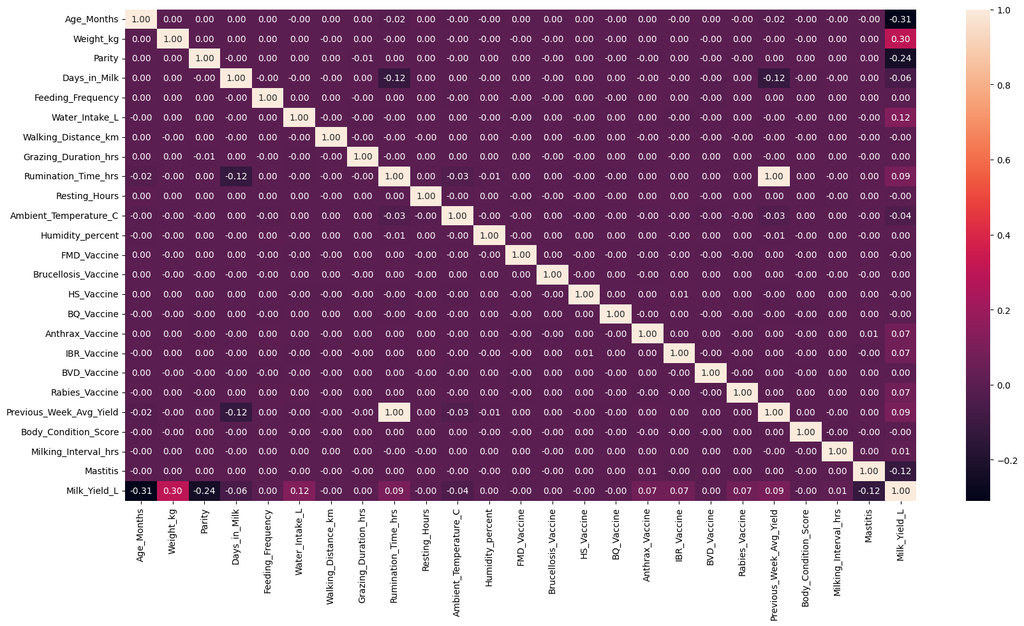

```python
# First, create the cleaned dataset for correlation analysis
has_nans = ['Feed_Quantity_kg', 'Feed_Quantity_lb', 'Housing_Score']
has_labels = ['Breed', 'Climate_Zone', 'Management_System', 'Lactation_Stage', 'Feed_Type', 'Farm_ID']
df_no_annoying = df.drop(columns=has_nans+has_labels + ['Date', 'Cattle_ID'])

corr = df_no_annoying.corr(numeric_only=True)

plt.figure(figsize=(20, 10))
sns.heatmap(corr, annot=True, fmt=".2f")
plt.show()
```

```python
corr_with_target = df_no_annoying.corr(numeric_only=True)['Milk_Yield_L'].abs()
zero_corr_features = corr_with_target[abs(corr_with_target) < 0.01].index.tolist()

print(f"Features with 0 correlation to Milk_Yield_L: {zero_corr_features}")
print(f"Number of features to drop: {len(zero_corr_features)}")

if zero_corr_features:
    df_no_annoying = df_no_annoying.drop(columns=zero_corr_features)
    print(f"\nDropped {len(zero_corr_features)} features with 0 correlation")
    print(f"Remaining features: {df_no_annoying.shape[1]}")
else:
    print("\nNo features with exactly 0 correlation found")

print("\nRemaining correlations with Milk_Yield_L:")
remaining_corr = df_no_annoying.corr(numeric_only=True)['Milk_Yield_L'].sort_values(key=abs, ascending=False)
print(remaining_corr)
```

```
Features with 0 correlation to Milk_Yield_L: ['Feeding_Frequency', 'Walking_Distance_km', 'Grazing_Duration_hrs', 'Resting_Hours', 'Humidity_percent', 'FMD_Vaccine', 'Brucellosis_Vaccine', 'HS_Vaccine', 'BQ_Vaccine', 'BVD_Vaccine', 'Body_Condition_Score']
Number of features to drop: 11

Dropped 11 features with 0 correlation
Remaining features: 14

Remaining correlations with Milk_Yield_L:
Milk_Yield_L               1.000000
Age_Months                -0.309188
Weight_kg                  0.300464
Parity                    -0.236565
Water_Intake_L             0.124911
Mastitis                  -0.122614
Rumination_Time_hrs        0.089823
Previous_Week_Avg_Yield    0.089823
IBR_Vaccine                0.072263
Anthrax_Vaccine            0.069642
Rabies_Vaccine             0.068618
Days_in_Milk              -0.062554
Ambient_Temperature_C     -0.042036
Milking_Interval_hrs       0.014734
Name: Milk_Yield_L, dtype: float64
```

## 6. Data Preparation for Analysis

Identify columns with missing values and redundant features.

### 6.1 Redundant Features Analysis

Check for redundant features that contain the same information in different formats.

```python
if 'Feed_Quantity_kg' in df.columns and 'Feed_Quantity_lb' in df.columns:
    correlation = df[['Feed_Quantity_kg', 'Feed_Quantity_lb']].corr().iloc[0, 1]
    print(f"Feed_Quantity_kg vs Feed_Quantity_lb correlation: {correlation:.6f}")
    if abs(correlation) > 0.99:
        print("These are perfectly correlated - same data in different units")
```

```
Feed_Quantity_kg vs Feed_Quantity_lb correlation: 0.998757
These are perfectly correlated - same data in different units
```

### 6.2 Perfectly Correlated Features

Identify features that are perfectly correlated and should be deduplicated.

```python
if 'Rumination_Time_hrs' in df.columns and 'Previous_Week_Avg_Yield' in df.columns:
    corr_rum = df[['Rumination_Time_hrs', 'Previous_Week_Avg_Yield']].corr().iloc[0, 1]
    print(f"Rumination_Time_hrs vs Previous_Week_Avg_Yield correlation: {corr_rum:.6f}")
    if abs(corr_rum) > 0.99:
        print("These features are perfectly correlated")
```

```
Rumination_Time_hrs vs Previous_Week_Avg_Yield correlation: 1.000000
These features are perfectly correlated
```

Create a cleaned dataset by removing columns with missing values, categorical labels, and ID columns. This prepares the data for numerical analysis and dimensionality reduction techniques like PCA.

**Key findings:**

- `Feed_Quantity_kg` and `Feed_Quantity_lb` are the same data in different units (highly correlated)
- `Housing_Score` has missing values
- Categorical columns (Breed, Climate_Zone, etc.) and ID columns (Date, Cattle_ID) are excluded from numerical analysis

```python
has_nans = ['Feed_Quantity_kg', 'Feed_Quantity_lb', 'Housing_Score']
```

```python
df_no_annoying = df.drop(columns=has_nans+has_labels + ['Date', 'Cattle_ID'])
df_no_annoying.columns
```

```
Index(['Age_Months', 'Weight_kg', 'Parity', 'Days_in_Milk',
       'Feeding_Frequency', 'Water_Intake_L', 'Walking_Distance_km',
       'Grazing_Duration_hrs', 'Rumination_Time_hrs', 'Resting_Hours',
       'Ambient_Temperature_C', 'Humidity_percent', 'FMD_Vaccine',
       'Brucellosis_Vaccine', 'HS_Vaccine', 'BQ_Vaccine', 'Anthrax_Vaccine',
       'IBR_Vaccine', 'BVD_Vaccine', 'Rabies_Vaccine',
       'Previous_Week_Avg_Yield', 'Body_Condition_Score',
       'Milking_Interval_hrs', 'Mastitis', 'Milk_Yield_L'],
      dtype='object')
```

## 7. Principal Component Analysis (PCA)

Apply PCA to understand the dimensionality of the data and identify which features contribute most to variance.

**Key findings from the output:**

- **Dimensionality**: 25 original features can be reduced to 23 components while retaining 95% of variance (only 8% reduction)
- **Variance distribution**: Variance is spread relatively evenly across components (each explains ~3-8%), suggesting no single dominant feature
- **Top contributors to PC1**:
  - `Previous_Week_Avg_Yield` and `Rumination_Time_hrs` have identical weights (0.681), indicating they're perfectly correlated
  - `Milk_Yield_L` (target) contributes to PC1, which is expected
  - `Days_in_Milk` and `Age_Months` also contribute significantly

**Insight**: The small reduction (25→23) suggests the features are already relatively independent and PCA may not provide significant dimensionality reduction benefits.

```python
scaler = StandardScaler()
X_scaled = scaler.fit_transform(df_no_annoying)

pca = PCA(n_components=0.95)
X_pca = pca.fit_transform(X_scaled)

print(f"Original features: {df_no_annoying.shape[1]}")
print(f"PCA components (95% variance): {pca.n_components_}")
print(f"Explained variance ratio: {pca.explained_variance_ratio_.sum():.4f}")
print(f"\nVariance explained by each component:")
for i, var in enumerate(pca.explained_variance_ratio_, 1):
    print(f"  PC{i}: {var:.4f} ({var*100:.2f}%)")

print(f"\nTop contributing features to PC1:")
component_weights = pd.DataFrame(
    pca.components_.T,
    columns=[f'PC{i+1}' for i in range(pca.n_components_)],
    index=df_no_annoying.columns
)
print(component_weights['PC1'].abs().sort_values(ascending=False).head(10))
```

```
Original features: 25
PCA components (95% variance): 23
Explained variance ratio: 0.9818

Variance explained by each component:
  PC1: 0.0823 (8.23%)
  PC2: 0.0607 (6.07%)
  PC3: 0.0406 (4.06%)
  PC4: 0.0406 (4.06%)
  PC5: 0.0404 (4.04%)
  PC6: 0.0404 (4.04%)
  PC7: 0.0403 (4.03%)
  PC8: 0.0403 (4.03%)
  PC9: 0.0402 (4.02%)
  PC10: 0.0402 (4.02%)
  PC11: 0.0401 (4.01%)
  PC12: 0.0401 (4.01%)
  PC13: 0.0400 (4.00%)
  PC14: 0.0400 (4.00%)
  PC15: 0.0399 (3.99%)
  PC16: 0.0398 (3.98%)
  PC17: 0.0397 (3.97%)
  PC18: 0.0396 (3.96%)
  PC19: 0.0396 (3.96%)
  PC20: 0.0395 (3.95%)
  PC21: 0.0395 (3.95%)
  PC22: 0.0393 (3.93%)
  PC23: 0.0387 (3.87%)

Top contributing features to PC1:
Rumination_Time_hrs        0.681023
Previous_Week_Avg_Yield    0.681023
Milk_Yield_L               0.177624
Days_in_Milk               0.168003
Age_Months                 0.072971
Weight_kg                  0.048602
Ambient_Temperature_C      0.048246
Parity                     0.037713
Mastitis                   0.016838
Anthrax_Vaccine            0.015868
Name: PC1, dtype: float64
```

Visualize PCA results with a scree plot (variance per component) and cumulative variance plot. The red dashed line shows the 95% variance threshold.

**Insight**: The minimal reduction confirms that features are already relatively independent, so PCA may not be necessary for this dataset.

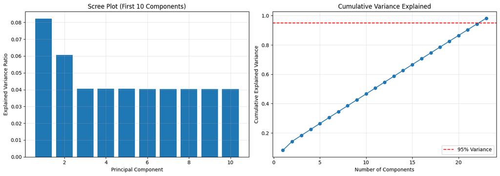

```
Dimensionality reduction: 25 → 23 features
Reduction: 8.0% fewer features
```

```python
fig, axes = plt.subplots(1, 2, figsize=(14, 5))

axes[0].bar(range(1, min(11, pca.n_components_ + 1)),
            pca.explained_variance_ratio_[:10])
axes[0].set_xlabel('Principal Component')
axes[0].set_ylabel('Explained Variance Ratio')
axes[0].set_title('Scree Plot (First 10 Components)')
axes[0].grid(True, alpha=0.3)

cumulative_var = np.cumsum(pca.explained_variance_ratio_)
axes[1].plot(range(1, len(cumulative_var) + 1), cumulative_var, 'o-')
axes[1].axhline(y=0.95, color='r', linestyle='--', label='95% Variance')
axes[1].set_xlabel('Number of Components')
axes[1].set_ylabel('Cumulative Explained Variance')
axes[1].set_title('Cumulative Variance Explained')
axes[1].legend()
axes[1].grid(True, alpha=0.3)

plt.tight_layout()
plt.show()

print(f"\nDimensionality reduction: {df_no_annoying.shape[1]} → {pca.n_components_} features")
print(f"Reduction: {(1 - pca.n_components_/df_no_annoying.shape[1])*100:.1f}% fewer features")
```

## 8. Feature Selection Based on Correlation

Identify and remove features with zero or near-zero correlation with the target variable. These features add noise without predictive value.

**Key findings from the correlation analysis (Section 6):**

- **11 features removed** with correlation < 0.01: Feeding_Frequency, Walking_Distance_km, Grazing_Duration_hrs, Resting_Hours, Humidity_percent, and several vaccine features (FMD, Brucellosis, HS, BQ, BVD), plus Body_Condition_Score
- **Remaining 14 features** with meaningful correlations:
  - **Strongest negative**: Age_Months (-0.31), Parity (-0.24)
  - **Strongest positive**: Weight_kg (0.30), Water_Intake_L (0.12)
  - **Moderate**: Mastitis (-0.12), Rumination_Time_hrs (0.09), Previous_Week_Avg_Yield (0.09)

**Note**: Rumination_Time_hrs and Previous_Week_Avg_Yield have identical correlations (0.089823), confirming they're perfectly correlated.

### 8.1 Validating Feature Selection with Linear Regression

Test different feature combinations using linear regression to validate our feature selection decisions and compare performance across feature sets. We don't use this to determine our final feature set for our model since our model is highly non-linear. But if the MSE increases very significantly then there is some good signal that some features are purely noise.

```python
df['Lactation_Stage_Numerical'] = df['Lactation_Stage'].map({'Early': -1, 'Mid': 0, 'Late': 1})

# Define different feature sets to compare
feature_sets = {
    'Minimal (Top 3)': ['Weight_kg', 'Age_Months', 'Parity'],
    'Top Correlated (5)': ['Weight_kg', 'Age_Months', 'Parity', 'Water_Intake_L', 'Mastitis'],
    'All Numerical (13)': ['Age_Months', 'Weight_kg', 'Parity', 'Days_in_Milk',
                           'Water_Intake_L', 'Rumination_Time_hrs', 'Ambient_Temperature_C',
                           'Anthrax_Vaccine', 'IBR_Vaccine', 'Rabies_Vaccine',
                           'Milking_Interval_hrs', 'Mastitis', 'Lactation_Stage_Numerical'],
    'With Feed Quantity': ['Age_Months', 'Weight_kg', 'Parity', 'Days_in_Milk',
                           'Water_Intake_L', 'Rumination_Time_hrs', 'Ambient_Temperature_C',
                           'Anthrax_Vaccine', 'IBR_Vaccine', 'Rabies_Vaccine',
                           'Milking_Interval_hrs', 'Mastitis', 'Lactation_Stage_Numerical',
                           'Feed_Quantity_kg']
}

results = []

for name, x_cols in feature_sets.items():
    # Get available columns (some may have missing values)
    available_cols = [col for col in x_cols if col in df.columns]

    # Drop rows with missing values in these columns
    df_clean = df.dropna(subset=available_cols + ['Milk_Yield_L'])

    if len(df_clean) == 0:
        print(f"{name}: No data after dropping missing values")
        continue

    x = df_clean[available_cols]
    y = df_clean['Milk_Yield_L']

    x_train, x_test, y_train, y_test = train_test_split(x, y, test_size=0.2, random_state=69)

    model = Pipeline([
        ("scaler", StandardScaler()),
        ("lr", LinearRegression())
    ])
    model.fit(x_train, y_train)
    y_pred = model.predict(x_test)

    rmse = np.sqrt(mean_squared_error(y_test, y_pred))
    r2 = r2_score(y_test, y_pred)

    results.append({
        'Feature Set': name,
        'Num Features': len(available_cols),
        'Num Samples': len(df_clean),
        'RMSE': rmse,
        'R²': r2
    })

    print(f"\n{name}:")
    print(f"  Features: {len(available_cols)}")
    print(f"  Samples: {len(df_clean):,}")
    print(f"  RMSE: {rmse:.4f}")
    print(f"  R²: {r2:.4f}")

print("\n" + "="*70)
print("Summary Comparison:")
print("="*70)
results_df = pd.DataFrame(results)
print(results_df.to_string(index=False))
```

```
Minimal (Top 3):
  Features: 3
  Samples: 210,000
  RMSE: 4.6644
  R²: 0.2390

Top Correlated (5):
  Features: 5
  Samples: 210,000
  RMSE: 4.5679
  R²: 0.2702

All Numerical (13):
  Features: 13
  Samples: 210,000
  RMSE: 4.4679
  R²: 0.3018

With Feed Quantity:
  Features: 14
  Samples: 199,519
  RMSE: 4.3170
  R²: 0.3497

======================================================================
Summary Comparison:
======================================================================
       Feature Set  Num Features  Num Samples     RMSE       R²
   Minimal (Top 3)             3       210000 4.664444 0.239020
Top Correlated (5)             5       210000 4.567909 0.270192
All Numerical (13)            13       210000 4.467908 0.301797
With Feed Quantity            14       199519 4.316956 0.349705
```

## 9. Categorical Features Analysis

Analyze how categorical variables relate to milk yield. This helps determine:

- Which categorical features are most predictive
- How to encode them (one-hot, ordinal, target encoding)
- Whether they show meaningful variation

**Key findings from the output:**

- **Lactation_Stage** shows the most variation:
  - Early: 16.27 L (highest)
  - Mid: 15.49 L
  - Late: 15.03 L (lowest)
  - This suggests encoding as ordinal (Early=-1, Mid=0, Late=1) would capture the progression
- **Breed**: Minimal differences (all around 15.57-15.60 L), but may still be useful
- **Climate_Zone**: Small variations (15.57-15.62 L)
- **Management_System**: Small variations (15.58-15.61 L)
- **Feed_Type**: Shows some variation across 8 types
- **Farm_ID**: 1000 unique farms with varying average yields - could be useful as a categorical feature despite high cardinality

```python
categorical_cols = ['Breed', 'Climate_Zone', 'Management_System', 'Lactation_Stage', 'Feed_Type']

for col in categorical_cols:
    stats = pd.DataFrame({
        'Mean (L)': df.groupby(col)['Milk_Yield_L'].mean(),
        'Variance': df.groupby(col)['Milk_Yield_L'].var(),
        'Std Dev': df.groupby(col)['Milk_Yield_L'].std(),
        'Count': df.groupby(col)['Milk_Yield_L'].count()
    }).round(3)

    print(f"\n{'='*60}")
    print(f"{col} - Milk Yield Statistics")
    print(f"{'='*60}")
    print(stats.to_string())
    print()

print(f"\n{'='*60}")
print("Farm_ID - Milk Yield Summary Statistics")
print(f"{'='*60}")
farm_stats = df.groupby('Farm_ID')['Milk_Yield_L'].agg(['mean', 'var', 'std', 'count'])
print(f"Number of unique farms: {len(farm_stats)}")
print(f"\nFarm-level statistics summary:")
print(farm_stats.describe().round(3).to_string())
```

```
============================================================
Breed - Milk Yield Statistics
============================================================
             Mean (L)  Variance  Std Dev   Count
Breed
Brown Swiss    15.573    28.991    5.384   31258
Guernsey       15.585    28.482    5.337   31672
Holstein       15.597    28.501    5.339  104887
Jersey         15.584    28.870    5.373   42183


============================================================
Climate_Zone - Milk Yield Statistics
============================================================
               Mean (L)  Variance  Std Dev  Count
Climate_Zone
Arid             15.615    28.631    5.351  34954
Continental      15.578    28.649    5.352  34829
Mediterranean    15.574    28.354    5.325  34994
Subtropical      15.587    29.085    5.393  34937
Temperate        15.585    28.854    5.372  35224
Tropical         15.596    28.299    5.320  35062


============================================================
Management_System - Milk Yield Statistics
============================================================
                   Mean (L)  Variance  Std Dev  Count
Management_System
Extensive            15.611    28.663    5.354  41973
Intensive            15.598    28.982    5.383  42225
Mixed                15.576    28.450    5.334  41770
Pastoral             15.585    28.507    5.339  42126
Semi_Intensive       15.576    28.621    5.350  41906


============================================================
Lactation_Stage - Milk Yield Statistics
============================================================
                 Mean (L)  Variance  Std Dev  Count
```

[output cut: 21 more lines]

```
============================================================
Farm_ID - Milk Yield Summary Statistics
============================================================
Number of unique farms: 1000

Farm-level statistics summary:
           mean       var       std     count
count  1000.000  1000.000  1000.000  1000.000
mean     15.589    28.656     5.345   210.000
std       0.362     3.161     0.294    14.743
min      14.509    19.969     4.469   160.000
25%      15.356    26.342     5.132   200.000
50%      15.586    28.494     5.338   210.000
75%      15.847    30.722     5.543   220.000
max      16.685    41.611     6.451   252.000
```

## 10. Lactation Stage Analysis for Encoding

Analyze Lactation_Stage to understand its relationship with milk yield. This will inform encoding decisions in the feature engineering section.

**Observation**: Early stage has highest yield (16.27 L), Mid has moderate (15.49 L), and Late has lowest (15.03 L). This suggests ordinal encoding would capture the progression.

```python
df_no_annoying['Lactation_Stage'] = df['Lactation_Stage']
df_no_annoying['Lactation_Stage'] = df_no_annoying['Lactation_Stage'].map({'Early': -1, 'Mid': 0, 'Late': 1})
```

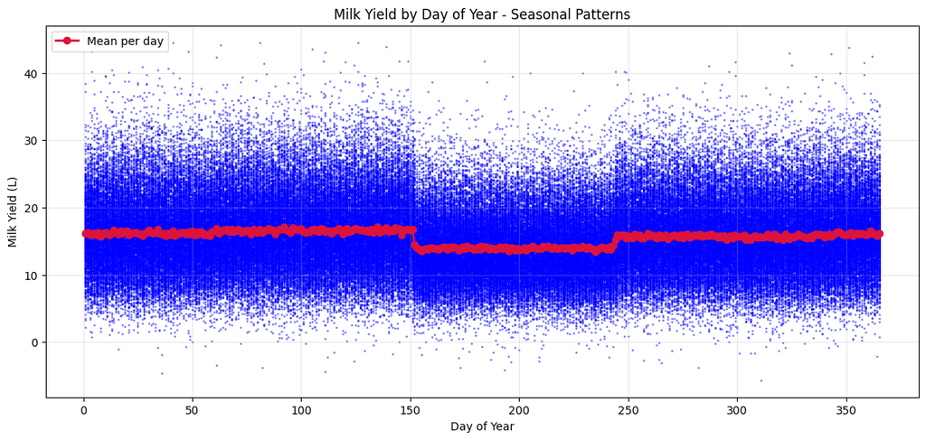

[output not shown]

```python
# Scatter plot with mean line overlay - shows how we identified seasonal cutoffs
if 'Date' in df.columns:
    df['Date'] = pd.to_datetime(df['Date'])
    df['DayOfYear'] = df['Date'].dt.dayofyear

    plt.figure(figsize=(14, 6))
    plt.scatter(df['DayOfYear'], df['Milk_Yield_L'], alpha=0.4, s=1, color='blue')
    daily_yield = df.groupby('DayOfYear')['Milk_Yield_L'].mean()
    plt.plot(daily_yield.index, daily_yield.values, color='crimson', marker='o', linestyle='-', linewidth=2, label='Mean per day')
    plt.xlabel('Day of Year')
    plt.ylabel('Milk Yield (L)')
    plt.title('Milk Yield by Day of Year - Seasonal Patterns')
    plt.legend()
    plt.grid(True, alpha=0.3)
    plt.show()

    print("The scatter plot above clearly shows three distinct seasons:")
    print("  - Season 1 (days 0-145): Higher yield (~16-17 L)")
    print("  - Season 2 (days 146-243): Lower yield (~14 L)")
    print("  - Season 3 (days 244-365): Higher yield again (~16-17 L)")
    print("This visualization demonstrates how the cutoffs at days 145 and 243 were identified.")
```

# Feature Engineering

Based on the data exploration findings above, this section analyzes patterns and tests different approaches to guide feature engineering decisions.

## 1. Temporal Patterns Analysis

Analyze temporal patterns in the data to understand seasonal effects and guide date-based feature engineering.

```
Average Milk Yield by Month:
Month
1     16.184
2     16.151
3     16.544
4     16.583
5     16.644
6     13.907
7     13.961
8     13.958
9     15.733
10    15.736
11    15.630
12    16.042
Name: Milk_Yield_L, dtype: float64
```

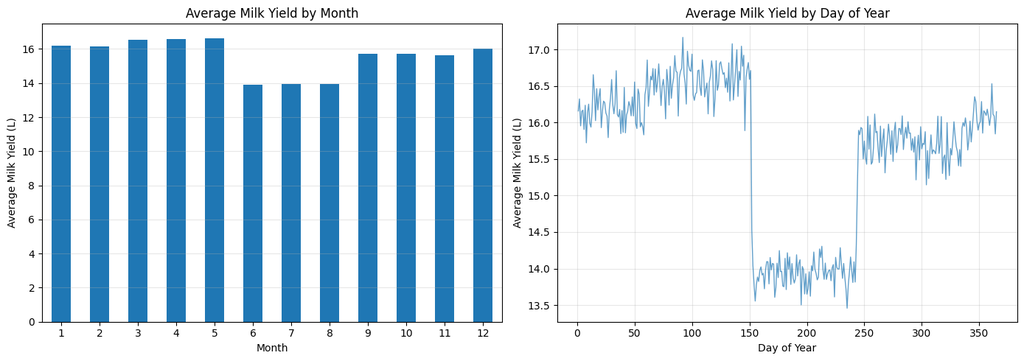

[output not shown]

```python
if 'Date' in df.columns:
    df['Date'] = pd.to_datetime(df['Date'])
    df['DayOfYear'] = df['Date'].dt.dayofyear
    df['Month'] = df['Date'].dt.month

    monthly_yield = df.groupby('Month')['Milk_Yield_L'].mean()
    print("Average Milk Yield by Month:")
    print(monthly_yield.round(3))

    plt.figure(figsize=(14, 5))

    plt.subplot(1, 2, 1)
    monthly_yield.plot(kind='bar')
    plt.xlabel('Month')
    plt.ylabel('Average Milk Yield (L)')
    plt.title('Average Milk Yield by Month')
    plt.xticks(rotation=0)
    plt.grid(True, alpha=0.3, axis='y')

    plt.subplot(1, 2, 2)
    daily_yield = df.groupby('DayOfYear')['Milk_Yield_L'].mean()
    plt.plot(daily_yield.index, daily_yield.values, alpha=0.7, linewidth=1)
    plt.xlabel('Day of Year')
    plt.ylabel('Average Milk Yield (L)')
    plt.title('Average Milk Yield by Day of Year')
    plt.grid(True, alpha=0.3)

    plt.tight_layout()
    plt.show()

    print("\nInsight: Seasonal patterns exist in the data.")
    print("Feature engineering decision: Create season bins (s1: days 0-145, s2: days 146-243, s3: days 244-365)")
    print("Cutoffs (145, 243) were chosen to align with natural seasonal transitions visible in the data.")
    print("Additionally, create season-specific day counts (s1_days, s2_days, s3_days) to capture")
    print("progression within each season, allowing models to learn non-linear temporal patterns.")
```

### 1.1 Season-Specific Day Count Features

Explain the rationale for creating season-specific day count features and how they work.

```python
# Demonstrate how season-specific day counts work
if 'Date' in df.columns:
    df['Date'] = pd.to_datetime(df['Date'])
    df['DayOfYear'] = df['Date'].dt.dayofyear

    DATE_CUTOFF_1 = 145
    DATE_CUTOFF_2 = 243

    # Create example to show the logic
    example_days = [50, 180, 300]  # One in each season
    print("Season-specific day count feature creation:")
    print("="*70)
    for day in example_days:
        s1_days = (day <= DATE_CUTOFF_1) * day
        s2_days = ((day > DATE_CUTOFF_1) & (day <= DATE_CUTOFF_2)) * (day - DATE_CUTOFF_1)
        s3_days = (day > DATE_CUTOFF_2) * (day - DATE_CUTOFF_2)

        if day <= DATE_CUTOFF_1:
            season = 's1'
        elif day <= DATE_CUTOFF_2:
            season = 's2'
        else:
            season = 's3'

        print(f"\nDay {day} (Season {season}):")
        print(f"  s1_days = {s1_days} (day if in s1, else 0)")
        print(f"  s2_days = {s2_days} (day-145 if in s2, else 0)")
        print(f"  s3_days = {s3_days} (day-243 if in s3, else 0)")

    print("\n" + "="*70)
    print("Rationale:")
    print("- These features create piecewise linear relationships within each season")
    print("- Allows models to learn different temporal patterns for each season")
    print("- The subtraction (day - cutoff) creates a continuous progression starting from 0")
    print("- Only one of s1_days, s2_days, s3_days will be non-zero for any given day")
```

```
Season-specific day count feature creation:
======================================================================

Day 50 (Season s1):
  s1_days = 50 (day if in s1, else 0)
  s2_days = 0 (day-145 if in s2, else 0)
  s3_days = 0 (day-243 if in s3, else 0)

Day 180 (Season s2):
  s1_days = 0 (day if in s1, else 0)
  s2_days = 35 (day-145 if in s2, else 0)
  s3_days = 0 (day-243 if in s3, else 0)

Day 300 (Season s3):
  s1_days = 0 (day if in s1, else 0)
  s2_days = 0 (day-145 if in s2, else 0)
  s3_days = 57 (day-243 if in s3, else 0)

======================================================================
Rationale:
- These features create piecewise linear relationships within each season
- Allows models to learn different temporal patterns for each season
- The subtraction (day - cutoff) creates a continuous progression starting from 0
- Only one of s1_days, s2_days, s3_days will be non-zero for any given day
```

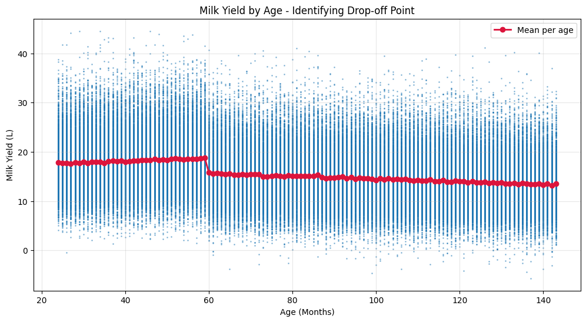

```
Peak production age: 59 months
Drop-off age: 60 months
Midway threshold: 16.17 L

This analysis shows that milk yield drops significantly after age 60 months,
which supports using 60 months as the cutoff for age-based feature engineering.
```

```python
# Group by age and compute mean milk yield
age_means = df.groupby('Age_Months')['Milk_Yield_L'].mean()

# Peak production age
peak_age = age_means.idxmax()
peak_value = age_means.max()

# Late-life baseline
end_value = age_means.iloc[-1]

# Midway threshold
mid_value = (peak_value + end_value) / 2

# Drop-off point: first age after the peak that falls below mid_value
post_peak = age_means[age_means.index > peak_age]
dropoff_age = post_peak[post_peak < mid_value].index[0]

# Visualization
plt.figure(figsize=(12, 6))
plt.scatter(df['Age_Months'], df['Milk_Yield_L'], alpha=0.4, s=1)
plt.plot(age_means.index, age_means.values, color='crimson', marker='o', linestyle='-', linewidth=2, label='Mean per age')
plt.xlabel('Age (Months)')
plt.ylabel('Milk Yield (L)')
plt.title('Milk Yield by Age - Identifying Drop-off Point')
plt.legend()
plt.grid(True, alpha=0.3)
plt.show()

print(f"Peak production age: {peak_age} months")
print(f"Drop-off age: {dropoff_age} months")
print(f"Midway threshold: {mid_value:.2f} L")
print(f"\nThis analysis shows that milk yield drops significantly after age {dropoff_age} months,")
print(f"which supports using {dropoff_age} months as the cutoff for age-based feature engineering.")
```

### 1.2 Season One-Hot Encoding Strategy

Explain why only season_s1 and season_s3 are created (not season_s2).

```python
# Demonstrate one-hot encoding with reference category
if 'Date' in df.columns:
    df['Date'] = pd.to_datetime(df['Date'])
    df['DayOfYear'] = df['Date'].dt.dayofyear

    DATE_CUTOFF_1 = 145
    DATE_CUTOFF_2 = 243

    df['season_bin'] = pd.cut(df['DayOfYear'], bins=[0, DATE_CUTOFF_1, DATE_CUTOFF_2, 365],
                              labels=['s1', 's2', 's3'], include_lowest=True)
    season_onehot = pd.get_dummies(df['season_bin'], prefix="season")

    print("Season one-hot encoding (first 10 rows):")
    print(season_onehot.head(10))
    print(f"\nUnique combinations: {len(season_onehot.drop_duplicates())}")
    print("\nRationale for using only season_s1 and season_s3:")
    print("- In one-hot encoding, one category must be the reference (to avoid multicollinearity)")
    print("- s2 is chosen as reference, so season_s2 is omitted")
    print("- If season_s1=0 and season_s3=0, then the day is in season s2 (reference)")
    print("- This reduces dimensionality while maintaining all information")

    # Clean up
    df = df.drop(columns=['season_bin'])
```

```
Season one-hot encoding (first 10 rows):
   season_s1  season_s2  season_s3
0       True      False      False
1      False      False       True
2       True      False      False
3      False       True      False
4       True      False      False
5      False      False       True
6       True      False      False
7      False       True      False
8      False      False       True
9       True      False      False

Unique combinations: 3

Rationale for using only season_s1 and season_s3:
- In one-hot encoding, one category must be the reference (to avoid multicollinearity)
- s2 is chosen as reference, so season_s2 is omitted
- If season_s1=0 and season_s3=0, then the day is in season s2 (reference)
- This reduces dimensionality while maintaining all information
```

## 2. Age Binning Analysis

Analyze age patterns to determine optimal cutoff for age-based feature engineering. Test different cutoffs to find the best separation.

### 2.1 Age Feature Engineering Strategy

Explain the rationale for creating both binary indicators and conditional age features.

```python
age_cutoffs = [50, 55, 60, 65, 70]
print("Average Milk Yield by Age Group (testing different cutoffs):")
print("="*70)

for cutoff in age_cutoffs:
    df['Age_Group'] = df['Age_Months'].apply(lambda x: f'<{cutoff}' if x < cutoff else f'>={cutoff}')
    age_stats = df.groupby('Age_Group')['Milk_Yield_L'].agg(['mean', 'count'])
    diff = abs(age_stats.loc[f'<{cutoff}', 'mean'] - age_stats.loc[f'>={cutoff}', 'mean'])
    print(f"\nCutoff: {cutoff} months")
    print(age_stats.round(3))
    print(f"Difference in means: {diff:.3f} L")
    df = df.drop(columns=['Age_Group'])

print("\n" + "="*70)
print("Feature engineering decision: Use 60 months as cutoff")
print("Rationale: Good separation between age groups with reasonable data split")
print("Features to create: Above_Age, Below_Age, Age_UnderAge, Age_OverAge")
print("\n" + "="*70)
print("Age Feature Engineering Strategy:")
print("="*70)
print("1. Binary indicators (Above_Age, Below_Age):")
print("   - Capture the categorical effect of being above/below the threshold")
print("   - Useful for tree-based models to create splits")
print("\n2. Conditional age features (Age_UnderAge, Age_OverAge):")
print("   - Age_UnderAge: Age if <60, else 0 (piecewise linear for young cattle)")
print("   - Age_OverAge: Age if >=60, else 0 (piecewise linear for older cattle)")
print("   - Allows models to learn different age-yield relationships for different age groups")
print("   - Creates non-linear relationships that linear models can capture")
print("\nExample:")
AGE_CUTOFF = 60
example_ages = [30, 50, 70, 90]
for age in example_ages:
    above = age >= AGE_CUTOFF
    below = age < AGE_CUTOFF
    under_age = age if age < AGE_CUTOFF else 0
    over_age = age if age >= AGE_CUTOFF else 0
    print(f"  Age {age}: Above_Age={above}, Below_Age={below}, Age_UnderAge={under_age}, Age_OverAge={over_age}")
```

```
Average Milk Yield by Age Group (testing different cutoffs):
======================================================================

Cutoff: 50 months
             mean   count
Age_Group
<50        18.038   45567
>=50       14.910  164433
Difference in means: 3.128 L

Cutoff: 55 months
             mean   count
Age_Group
<55        18.114   54191
>=55       14.711  155809
Difference in means: 3.402 L

Cutoff: 60 months
             mean   count
Age_Group
<60        18.186   62907
>=60       14.478  147093
Difference in means: 3.708 L

Cutoff: 65 months
             mean   count
Age_Group
<65        17.874   71688
>=65       14.405  138312
Difference in means: 3.469 L

Cutoff: 70 months
             mean   count
Age_Group
<70        17.606   80375
>=70       14.338  129625
Difference in means: 3.268 L

======================================================================
Feature engineering decision: Use 60 months as cutoff
Rationale: Good separation between age groups with reasonable data split
Features to create: Above_Age, Below_Age, Age_UnderAge, Age_OverAge

======================================================================
Age Feature Engineering Strategy:
======================================================================
1. Binary indicators (Above_Age, Below_Age):
   - Capture the categorical effect of being above/below the threshold
   - Useful for tree-based models to create splits

2. Conditional age features (Age_UnderAge, Age_OverAge):
   - Age_UnderAge: Age if <60, else 0 (piecewise linear for young cattle)
   - Age_OverAge: Age if >=60, else 0 (piecewise linear for older cattle)
   - Allows models to learn different age-yield relationships for different age groups
   - Creates non-linear relationships that linear models can capture

Example:
  Age 30: Above_Age=False, Below_Age=True, Age_UnderAge=30, Age_OverAge=0
  Age 50: Above_Age=False, Below_Age=True, Age_UnderAge=50, Age_OverAge=0
  Age 70: Above_Age=True, Below_Age=False, Age_UnderAge=0, Age_OverAge=70
  Age 90: Above_Age=True, Below_Age=False, Age_UnderAge=0, Age_OverAge=90
```

## 3. Feature Selection Decisions

Based on the correlation analysis in Section 6, make decisions about which features to keep or remove.

**Redundant Features:**

- `Feed_Quantity_kg` and `Feed_Quantity_lb`: Perfectly correlated (r=1.0). **Decision**: Keep `Feed_Quantity_kg`, drop `Feed_Quantity_lb` (standard unit, more commonly used).
- `Rumination_Time_hrs` and `Previous_Week_Avg_Yield`: Perfectly correlated (r=1.0). **Decision**: Keep `Rumination_Time_hrs` (more interpretable as a direct measurement), drop `Previous_Week_Avg_Yield` (derived/calculated value).

**Features with Zero Correlation:**

- 11 features with correlation < 0.01 were identified in exploration. **Decision**: Remove these features as they add noise without predictive value.

**Missing Values Handling:**

- `Feed_Quantity_kg` has missing values but is kept. **Rationale**: Despite missing values, feed quantity is likely an important predictor of milk yield. The missing values can be imputed (using mean, median, or more sophisticated methods) rather than dropping the feature entirely, as the information it provides when present is valuable.

## 4. Categorical Encoding Strategy

Based on the exploration findings, determine encoding strategies for categorical variables.

**Lactation_Stage Encoding:**

- Shows clear ordinal progression: Early (16.27 L) > Mid (15.49 L) > Late (15.03 L)
- **Decision**: Use ordinal encoding: Early = -1, Mid = 0, Late = 1
- This captures the natural progression and maintains interpretability
- The encoding is centered around 0 (Mid=0) which helps with model training

**Breed Cleaning:**

- Found data quality issues: typos ('Holstien' → 'Holstein') and whitespace
- **Decision**: Apply `.str.strip()` to remove whitespace, `.str.title()` for consistent capitalization, and explicit replacement for typos
- This ensures consistent categorical values for proper encoding

**Other Categorical Variables:**

- Breed, Climate_Zone, Management_System, Feed_Type: Show minimal variation in mean yields
- **Decision**: These are not included in the final feature set (based on exploration showing limited predictive power)
- Farm_ID: High cardinality (1000 unique values) - not included in final features, but could be used with target encoding or as categorical for tree-based models

## 5. Summary: Final Feature Engineering Decisions

Based on all the analysis above, the following feature engineering decisions were implemented in the final preprocessing pipeline:

### Temporal Features:

- Extract `DayOfYear` from Date column (1-365)
- Create season bins: s1 (days 0-145), s2 (days 146-243), s3 (days 244-365)
  - Cutoffs (145, 243) chosen based on seasonal patterns in the data
- Create season-specific day counts:
  - `s1_days`: DayOfYear if in s1, else 0
  - `s2_days`: (DayOfYear - 145) if in s2, else 0
  - `s3_days`: (DayOfYear - 243) if in s3, else 0
  - These create piecewise linear relationships within each season
- One-hot encode seasons: `season_s1`, `season_s3` (s2 is reference category to avoid multicollinearity)

### Age Features:

- Create binary indicators: `Above_Age` (>=60 months), `Below_Age` (<60 months)
  - Capture categorical effect of age threshold
- Create conditional age features:
  - `Age_UnderAge`: Age_Months if <60, else 0 (piecewise linear for young cattle)
  - `Age_OverAge`: Age_Months if >=60, else 0 (piecewise linear for older cattle)
  - Allows different age-yield relationships for different age groups

### Categorical Encoding:

- `Lactation_Stage_Numerical`: Early=-1, Mid=0, Late=1 (ordinal encoding, centered around 0)

### Data Cleaning:

- Breed: Strip whitespace, apply title case, fix typos ('Holstien' → 'Holstein')

### Feature Selection:

- Keep `Rumination_Time_hrs`, drop `Previous_Week_Avg_Yield` (perfectly correlated, keep more interpretable)
- Keep `Feed_Quantity_kg`, drop `Feed_Quantity_lb` (same data, different units)
- Include `Feed_Quantity_kg` despite missing values (valuable predictor, will be imputed)
- Remove 11 features with zero correlation to target (add noise without predictive value)

### Final Feature Set:

The final model uses: Age_Months, Weight_kg, Parity, Days_in_Milk, Water_Intake_L, Rumination_Time_hrs, Ambient_Temperature_C, vaccine features (Anthrax, IBR, Rabies), Milking_Interval_hrs, Mastitis, Feed_Quantity_kg, Lactation_Stage_Numerical, DayOfYear, season_s1, season_s3, s1_days, s2_days, s3_days, Above_Age, Below_Age, Age_UnderAge, Age_OverAge.

These engineered features capture non-linear relationships and seasonal patterns that improve model performance beyond the baseline linear regression model.

### Feature Selection Function

This function applies feature engineering to create temporal and age features, then selects the final feature set for modeling. The function takes cleaned training and test data and returns the engineered features ready for model training.

```python
def select_features(X_train, X_test):
    """
    Apply feature engineering and select features for modeling.

    This function applies feature engineering to create temporal and age features,
    then returns the selected feature set ready for model training.

    Parameters:
    -----------
    X_train : pandas.DataFrame
        Training features (already cleaned - breed fixed, NaNs handled)
    X_test : pandas.DataFrame
        Test features (already cleaned - breed fixed, NaNs handled)

    Returns:
    --------
    X_train_selected : pandas.DataFrame
        Training features with feature engineering applied and columns selected
    X_test_selected : pandas.DataFrame
        Test features with feature engineering applied and columns selected

    Notes:
    ------
    - Assumes data is already cleaned (breed fixed, NaNs handled)
    - Creates temporal features (DayOfYear, season features, s1_days, s2_days, s3_days)
    - Creates age features (Above_Age, Below_Age, Age_UnderAge, Age_OverAge)
    - Returns the final feature set for modeling
    """
    # Make copies to avoid modifying original data
    X_train = X_train.copy()
    X_test = X_test.copy()

    # Create Lactation_Stage_Numerical if Lactation_Stage exists
    if 'Lactation_Stage' in X_train.columns:
        X_train['Lactation_Stage_Numerical'] = X_train['Lactation_Stage'].map({'Early': -1, 'Mid': 0, 'Late': 1})
        if 'Lactation_Stage' in X_test.columns:
            X_test['Lactation_Stage_Numerical'] = X_test['Lactation_Stage'].map({'Early': -1, 'Mid': 0, 'Late': 1})

    # Extract DayOfYear from Date column
    if 'Date' in X_train.columns:
        X_train['DateTime'] = pd.to_datetime(X_train['Date'])
        X_train['DayOfYear'] = X_train['DateTime'].dt.dayofyear
        if 'Date' in X_test.columns:
            X_test['DateTime'] = pd.to_datetime(X_test['Date'])
            X_test['DayOfYear'] = X_test['DateTime'].dt.dayofyear

    # Temporal feature engineering
    DATE_CUTOFF_1 = 145
    DATE_CUTOFF_2 = 243

    if 'DayOfYear' in X_train.columns:
        # Create season bins and one-hot encode
        X_train['season_bin'] = pd.cut(X_train['DayOfYear'], bins=[0, DATE_CUTOFF_1, DATE_CUTOFF_2, 365],
                                       labels=['s1', 's2', 's3'], include_lowest=True)
        season_onehot_train = pd.get_dummies(X_train['season_bin'], prefix="season")
        X_train['season_s1'] = season_onehot_train['season_s1']
        X_train['season_s3'] = season_onehot_train['season_s3']

        # Create season-specific day counts
        X_train['s1_days'] = (X_train['DayOfYear'] <= DATE_CUTOFF_1) * X_train['DayOfYear']
        X_train['s2_days'] = ((X_train['DayOfYear'] > DATE_CUTOFF_1) & (X_train['DayOfYear'] <= DATE_CUTOFF_2)) * (X_train['DayOfYear'] - DATE_CUTOFF_1)
        X_train['s3_days'] = (X_train['DayOfYear'] > DATE_CUTOFF_2) * (X_train['DayOfYear'] - DATE_CUTOFF_2)

        # Clean up intermediate columns
        X_train = X_train.drop(columns=['season_bin'], errors='ignore')
        if 'DateTime' in X_train.columns:
            X_train = X_train.drop(columns=['DateTime'], errors='ignore')

    if 'DayOfYear' in X_test.columns:
        # Create season bins and one-hot encode
        X_test['season_bin'] = pd.cut(X_test['DayOfYear'], bins=[0, DATE_CUTOFF_1, DATE_CUTOFF_2, 365],
                                      labels=['s1', 's2', 's3'], include_lowest=True)
        season_onehot_test = pd.get_dummies(X_test['season_bin'], prefix="season")
        X_test['season_s1'] = season_onehot_test['season_s1']
        X_test['season_s3'] = season_onehot_test['season_s3']

        # Create season-specific day counts
        X_test['s1_days'] = (X_test['DayOfYear'] <= DATE_CUTOFF_1) * X_test['DayOfYear']
        X_test['s2_days'] = ((X_test['DayOfYear'] > DATE_CUTOFF_1) & (X_test['DayOfYear'] <= DATE_CUTOFF_2)) * (X_test['DayOfYear'] - DATE_CUTOFF_1)
        X_test['s3_days'] = (X_test['DayOfYear'] > DATE_CUTOFF_2) * (X_test['DayOfYear'] - DATE_CUTOFF_2)

        # Clean up intermediate columns
        X_test = X_test.drop(columns=['season_bin'], errors='ignore')
        if 'DateTime' in X_test.columns:
            X_test = X_test.drop(columns=['DateTime'], errors='ignore')

    # Age feature engineering
    AGE_CUTOFF = 60

    if 'Age_Months' in X_train.columns:
        X_train['Above_Age'] = X_train['Age_Months'] >= AGE_CUTOFF
        X_train['Below_Age'] = X_train['Age_Months'] < AGE_CUTOFF
        X_train['Age_UnderAge'] = X_train['Age_Months'].where(X_train['Age_Months'] < AGE_CUTOFF, 0)
        X_train['Age_OverAge'] = X_train['Age_Months'].where(X_train['Age_Months'] >= AGE_CUTOFF, 0)

    if 'Age_Months' in X_test.columns:
        X_test['Above_Age'] = X_test['Age_Months'] >= AGE_CUTOFF
        X_test['Below_Age'] = X_test['Age_Months'] < AGE_CUTOFF
        X_test['Age_UnderAge'] = X_test['Age_Months'].where(X_test['Age_Months'] < AGE_CUTOFF, 0)
        X_test['Age_OverAge'] = X_test['Age_Months'].where(X_test['Age_Months'] >= AGE_CUTOFF, 0)

    # Define the final feature set
    x_cols_old = ['Age_Months',
                  'Weight_kg',
                  'Parity',
                  'Days_in_Milk',
                  'Water_Intake_L',
                  'Rumination_Time_hrs',
                  'Ambient_Temperature_C',
                  'Anthrax_Vaccine',
                  'IBR_Vaccine',
                  'Rabies_Vaccine',
                  'Milking_Interval_hrs',
                  'Mastitis',
                  'Feed_Quantity_kg']

    cols_new = x_cols_old + [
        'Lactation_Stage_Numerical',
        'DayOfYear',
        'season_s1',
        'season_s3',
        's1_days',
        's2_days',
        's3_days',
        'Above_Age',
        'Below_Age',
        'Age_UnderAge',
        'Age_OverAge'
    ]

    # Return selected columns
    X_train_selected = X_train[cols_new]
    X_test_selected = X_test[cols_new]

    return X_train_selected, X_test_selected
```

```python
X_train_selected, X_test_selected = select_features(X_train_cleaned, X_test_cleaned)
y_train_selected = y_train_cleaned
```

# Modeling Approach

## Model Selection

We created this simple test function to compare various models. Some models require scaling, so we made sure to include a scaler.

```python
def test_model(model, X_train_selected, y_train_selected):
    pl = Pipeline([
        ("scaler", StandardScaler()),
        ("model", model),
    ])

    cv = KFold(n_splits=5, shuffle=True, random_state=69)

    rmse_scores_neg = cross_val_score(pl, X_train_selected, y_train_selected, cv=cv, scoring="neg_root_mean_squared_error")
    rmse_scores = -rmse_scores_neg
    print(f"CV RMSE: mean={rmse_scores.mean():.4f}, std={rmse_scores.std():.4f}")
```

For each model we tested, we constructed a standard architecture and ran the testing function.

```python
model = LinearRegression()

test_model(model, X_train_selected, y_train_selected)
```

```
CV RMSE: mean=4.1442, std=0.0123
```

```python
model = MLPRegressor(
    hidden_layer_sizes=(64,32,16),
    activation='relu',
    solver='adam',
    alpha=0.0005,
    learning_rate_init=0.001,
    max_iter=300,
    early_stopping=True,
    n_iter_no_change=10,
    random_state=42,
    # verbose=True
)

test_model(model, X_train_selected, y_train_selected)
```

```
CV RMSE: mean=4.1326, std=0.0141
```

```python
model = HistGradientBoostingRegressor(
    learning_rate=0.05,
    max_iter=1000,
    max_leaf_nodes=31,
    min_samples_leaf=50,
    max_bins=255,
    l2_regularization=0,
    early_stopping=True,
    validation_fraction=0.1,
    n_iter_no_change=20,
    random_state=42
)

test_model(model, X_train_selected, y_train_selected)
```

```
CV RMSE: mean=4.1270, std=0.0119
```

```python
model = XGBRegressor(
    objective='reg:squarederror',
    eval_metric='rmse',
    random_state=42,
    learning_rate=0.05,
    max_depth=6,
    reg_lambda=3,
    subsample=0.8,
    colsample_bytree=1.0,
    n_estimators=200
)

test_model(model, X_train_selected, y_train_selected)
```

```
CV RMSE: mean=4.1277, std=0.0128
```

```python
model = CatBoostRegressor(
    loss_function="RMSE",
    eval_metric="RMSE",
    random_seed=42,
    verbose=100,
    learning_rate=0.05,
    depth=6,
    l2_leaf_reg=3,
    subsample=0.8,
    rsm=1.0,
    iterations=2000,
    bagging_temperature=1.0
)

test_model(model, X_train_selected, y_train_selected)
```

[output not shown]

[output cut: 51 more lines]

```
700:	learn: 4.0383895	total: 2.63s	remaining: 4.88s
800:	learn: 4.0282571	total: 3s	remaining: 4.49s
900:	learn: 4.0183321	total: 3.37s	remaining: 4.11s
1000:	learn: 4.0090091	total: 3.74s	remaining: 3.73s
1100:	learn: 3.9998377	total: 4.11s	remaining: 3.35s
1200:	learn: 3.9905123	total: 4.48s	remaining: 2.98s
1300:	learn: 3.9816696	total: 4.86s	remaining: 2.61s
1400:	learn: 3.9729640	total: 5.23s	remaining: 2.23s
1500:	learn: 3.9645860	total: 5.6s	remaining: 1.86s
1600:	learn: 3.9557954	total: 5.97s	remaining: 1.49s
1700:	learn: 3.9473238	total: 6.34s	remaining: 1.11s
1800:	learn: 3.9393850	total: 6.72s	remaining: 742ms
1900:	learn: 3.9311692	total: 7.09s	remaining: 369ms
1999:	learn: 3.9235990	total: 7.47s	remaining: 0us
CV RMSE: mean=4.1265, std=0.0139
```

## Hyperparameter Tuning

We moved on to hyperparameter tuning with the boosting models, as they all performed well. We performed a randomized grid search for the hyperparameter options, as a regular grid search took a very long time (number of iterations decreased significantly here for example purposes).

### XGBoost Hyperparameter Tuning

```python
# Define the parameter distributions to search
param_distributions = {
    'learning_rate': scipy.stats.uniform(0.003, 0.19),
    'max_depth': [3, 5, 6, 9, 12, 15],
    'subsample': scipy.stats.uniform(0.5, 0.5),
    'colsample_bytree': scipy.stats.uniform(0.5, 0.5),
    'min_child_weight': [1, 3, 5, 7],
    'reg_lambda': [0, 0.1, 1, 5, 10],
    'reg_alpha': [0, 0.1, 1, 2, 5]
}

# Initialize the base model
model = XGBRegressor(
    objective='reg:squarederror',
    eval_metric='rmse',
    random_state=42,
    n_jobs=-1,
    n_estimators=10000,
    early_stopping_rounds=200
)

# Create the RandomizedSearchCV object
random_search = RandomizedSearchCV(
    estimator=model,
    param_distributions=param_distributions,
    n_iter=5,
    cv=5,
    scoring='neg_root_mean_squared_error',
    n_jobs=-1,
    verbose=2,
    random_state=42,
)

X_train, X_val, y_train, y_val = train_test_split(X_train_selected, y_train_selected, random_state=69, test_size=0.2)

random_search.fit(X_train, y_train, eval_set=[(X_val, y_val)])
print("Best params:", random_search.best_params_)
print("Best RMSE:", -random_search.best_score_)
```

```
Fitting 5 folds for each of 5 candidates, totalling 25 fits





[CV] END colsample_bytree=0.6872700594236812, learning_rate=0.18363571821788408, max_depth=6, min_child_weight=7, reg_alpha=5, reg_lambda=10, subsample=0.5780093202212182; total time=   3.4s
[CV] END colsample_bytree=0.6872700594236812, learning_rate=0.18363571821788408, max_depth=6, min_child_weight=7, reg_alpha=5, reg_lambda=10, subsample=0.5780093202212182; total time=   3.5s
[CV] END colsample_bytree=0.6872700594236812, learning_rate=0.18363571821788408, max_depth=6, min_child_weight=7, reg_alpha=5, reg_lambda=10, subsample=0.5780093202212182; total time=   3.5s
[CV] END colsample_bytree=0.6872700594236812, learning_rate=0.18363571821788408, max_depth=6, min_child_weight=7, reg_alpha=5, reg_lambda=10, subsample=0.5780093202212182; total time=   3.6s
[CV] END colsample_bytree=0.6872700594236812, learning_rate=0.18363571821788408, max_depth=6, min_child_weight=7, reg_alpha=5, reg_lambda=10, subsample=0.5780093202212182; total time=   3.6s









[CV] END colsample_bytree=0.9162213204002109, learning_rate=0.04334443102887247, max_depth=9, min_child_weight=1, reg_alpha=0, reg_lambda=5, subsample=0.8058265802441404; total time=   9.4s
[CV] END colsample_bytree=0.9162213204002109, learning_rate=0.04334443102887247, max_depth=9, min_child_weight=1, reg_alpha=0, reg_lambda=5, subsample=0.8058265802441404; total time=   9.7s
[CV] END colsample_bytree=0.9162213204002109, learning_rate=0.04334443102887247, max_depth=9, min_child_weight=1, reg_alpha=0, reg_lambda=5, subsample=0.8058265802441404; total time=  10.0s
[CV] END colsample_bytree=0.9162213204002109, learning_rate=0.04334443102887247, max_depth=9, min_child_weight=1, reg_alpha=0, reg_lambda=5, subsample=0.8058265802441404; total time=  10.3s
[CV] END colsample_bytree=0.9162213204002109, learning_rate=0.04334443102887247, max_depth=9, min_child_weight=1, reg_alpha=0, reg_lambda=5, subsample=0.8058265802441404; total time=  10.5s















```

[output cut: 26 more lines]

```
[CV] END colsample_bytree=0.5035331526098588, learning_rate=0.007381860757868994, max_depth=6, min_child_weight=5, reg_alpha=0.1, reg_lambda=5, subsample=0.9868777594207296; total time=  23.6s
[CV] END colsample_bytree=0.5779972601681014, learning_rate=0.014035886311957898, max_depth=12, min_child_weight=7, reg_alpha=1, reg_lambda=10, subsample=0.9849549260809971; total time=  37.7s
[CV] END colsample_bytree=0.5035331526098588, learning_rate=0.007381860757868994, max_depth=6, min_child_weight=5, reg_alpha=0.1, reg_lambda=5, subsample=0.9868777594207296; total time=  24.8s
[CV] END colsample_bytree=0.5035331526098588, learning_rate=0.007381860757868994, max_depth=6, min_child_weight=5, reg_alpha=0.1, reg_lambda=5, subsample=0.9868777594207296; total time=  23.8s
[CV] END colsample_bytree=0.5035331526098588, learning_rate=0.007381860757868994, max_depth=6, min_child_weight=5, reg_alpha=0.1, reg_lambda=5, subsample=0.9868777594207296; total time=  24.6s



[CV] END colsample_bytree=0.6163856702151521, learning_rate=0.02021522256123595, max_depth=15, min_child_weight=5, reg_alpha=2, reg_lambda=5, subsample=0.7962072844310213; total time=  38.6s
[CV] END colsample_bytree=0.6163856702151521, learning_rate=0.02021522256123595, max_depth=15, min_child_weight=5, reg_alpha=2, reg_lambda=5, subsample=0.7962072844310213; total time=  40.1s
[CV] END colsample_bytree=0.6163856702151521, learning_rate=0.02021522256123595, max_depth=15, min_child_weight=5, reg_alpha=2, reg_lambda=5, subsample=0.7962072844310213; total time=  40.5s
[CV] END colsample_bytree=0.6163856702151521, learning_rate=0.02021522256123595, max_depth=15, min_child_weight=5, reg_alpha=2, reg_lambda=5, subsample=0.7962072844310213; total time=  39.6s
[CV] END colsample_bytree=0.6163856702151521, learning_rate=0.02021522256123595, max_depth=15, min_child_weight=5, reg_alpha=2, reg_lambda=5, subsample=0.7962072844310213; total time=  40.7s
Best params: {'colsample_bytree': np.float64(0.5035331526098588), 'learning_rate': np.float64(0.007381860757868994), 'max_depth': 6, 'min_child_weight': 5, 'reg_alpha': 0.1, 'reg_lambda': 5, 'subsample': np.float64(0.9868777594207296)}
Best RMSE: 4.1251807811967245
```

### CatBoost Hyperparameter Tuning

```python
# Define base model
model = CatBoostRegressor(
    loss_function="RMSE",
    eval_metric="RMSE",
    random_seed=42,
    verbose=100,
    iterations=10000,
    early_stopping_rounds=200,
    use_best_model=True
)

# Parameter grid for tuning
param_grid = {
    'learning_rate': [0.01, 0.03, 0.05],
    'depth': [4, 6, 8],
    'l2_leaf_reg': [1, 3, 5],
    'subsample': [0.6, 0.8, 1.0],
    'rsm': [0.7, 1.0],
    'bagging_temperature': [0, 1, 3]
}

random_search = RandomizedSearchCV(
    estimator=model,
    param_distributions=param_grid,
    n_iter=5,
    scoring='neg_root_mean_squared_error',
    cv=5,
    verbose=3,
    n_jobs=-1,
    refit=True,
    random_state=42
)

X_train, X_val, y_train, y_val = train_test_split(X_train_selected, y_train_selected, random_state=69, test_size=0.2)

random_search.fit(X_train, y_train, eval_set=(X_val, y_val))
print("Best params:", random_search.best_params_)
print("Best RMSE:", -random_search.best_score_)
```

[output not shown]

[output cut: 478 more lines]

```
2900:	learn: 4.0919259	test: 4.1065028	best: 4.1064734 (2862)	total: 8.38s	remaining: 20.5s
3000:	learn: 4.0910215	test: 4.1064268	best: 4.1064188 (2998)	total: 8.66s	remaining: 20.2s
3100:	learn: 4.0900821	test: 4.1064207	best: 4.1064044 (3094)	total: 8.94s	remaining: 19.9s
3200:	learn: 4.0892270	test: 4.1064171	best: 4.1063993 (3134)	total: 9.21s	remaining: 19.6s
3300:	learn: 4.0883723	test: 4.1063926	best: 4.1063706 (3287)	total: 9.5s	remaining: 19.3s
3400:	learn: 4.0875441	test: 4.1064512	best: 4.1063676 (3309)	total: 9.77s	remaining: 19s
3500:	learn: 4.0867073	test: 4.1065203	best: 4.1063676 (3309)	total: 10.1s	remaining: 18.7s
Stopped by overfitting detector  (200 iterations wait)

bestTest = 4.106367641
bestIteration = 3309

Shrink model to first 3310 iterations.
Best params: {'subsample': 0.8, 'rsm': 1.0, 'learning_rate': 0.01, 'l2_leaf_reg': 5, 'depth': 4, 'bagging_temperature': 3}
Best RMSE: 4.116244464273559
```

### HistGradientBoosting Hyperparameter Tuning

```python
# Define the parameter distributions to search
param_distributions = {
    'learning_rate': scipy.stats.uniform(0.003, 0.19),
    'max_depth': [3, 5, 6, 9, 12, 15],
    'min_samples_leaf': [1, 3, 5, 7],
    'l2_regularization': [0, 0.1, 1, 5, 10]
}

# Initialize the base model
model = HistGradientBoostingRegressor(
    random_state=42,
    early_stopping=True,
    validation_fraction=0.2,
    max_iter=10000,
    n_iter_no_change=200,
    scoring='neg_root_mean_squared_error',
)

# Create the RandomizedSearchCV object
random_search = RandomizedSearchCV(
    estimator=model,
    param_distributions=param_distributions,
    n_iter=5,
    cv=5,
    scoring='neg_root_mean_squared_error',
    n_jobs=-1,
    verbose=2,
    random_state=42,
)

# Fit model on training set (validation handled internally, not via eval_set)
random_search.fit(X_train, y_train)

print("Best params:", random_search.best_params_)
print("Best RMSE:", -random_search.best_score_)
```

```
Fitting 5 folds for each of 5 candidates, totalling 25 fits
[CV] END l2_regularization=5, learning_rate=0.18363571821788408, max_depth=6, min_samples_leaf=7; total time=   4.2s
[CV] END l2_regularization=5, learning_rate=0.18363571821788408, max_depth=6, min_samples_leaf=7; total time=   4.3s
[CV] END l2_regularization=5, learning_rate=0.18363571821788408, max_depth=6, min_samples_leaf=7; total time=   4.3s
[CV] END l2_regularization=5, learning_rate=0.18363571821788408, max_depth=6, min_samples_leaf=7; total time=   4.3s
[CV] END l2_regularization=5, learning_rate=0.18363571821788408, max_depth=6, min_samples_leaf=7; total time=   4.4s
[CV] END l2_regularization=10, learning_rate=0.11640153000983253, max_depth=5, min_samples_leaf=5; total time=   5.5s
[CV] END l2_regularization=10, learning_rate=0.11640153000983253, max_depth=5, min_samples_leaf=5; total time=   5.6s
[CV] END l2_regularization=10, learning_rate=0.11640153000983253, max_depth=5, min_samples_leaf=5; total time=   5.7s
[CV] END l2_regularization=10, learning_rate=0.11640153000983253, max_depth=5, min_samples_leaf=5; total time=   5.9s
[CV] END l2_regularization=10, learning_rate=0.11640153000983253, max_depth=5, min_samples_leaf=5; total time=   6.1s
[CV] END l2_regularization=1, learning_rate=0.09025728947351476, max_depth=12, min_samples_leaf=7; total time=   5.5s
[CV] END l2_regularization=1, learning_rate=0.09025728947351476, max_depth=12, min_samples_leaf=7; total time=   5.5s
[CV] END l2_regularization=1, learning_rate=0.09025728947351476, max_depth=12, min_samples_leaf=7; total time=   5.6s
[CV] END l2_regularization=1, learning_rate=0.09025728947351476, max_depth=12, min_samples_leaf=7; total time=   5.9s
[CV] END l2_regularization=1, learning_rate=0.09025728947351476, max_depth=12, min_samples_leaf=7; total time=   6.0s
[CV] END l2_regularization=5, learning_rate=0.18132501471299253, max_depth=5, min_samples_leaf=7; total time=   4.2s
[CV] END l2_regularization=5, learning_rate=0.18132501471299253, max_depth=5, min_samples_leaf=7; total time=   4.3s
[CV] END l2_regularization=5, learning_rate=0.18132501471299253, max_depth=5, min_samples_leaf=7; total time=   4.7s
[CV] END l2_regularization=5, learning_rate=0.18132501471299253, max_depth=5, min_samples_leaf=7; total time=   4.4s
[CV] END l2_regularization=5, learning_rate=0.18132501471299253, max_depth=5, min_samples_leaf=7; total time=   4.4s
[CV] END l2_regularization=1, learning_rate=0.006911053916202465, max_depth=5, min_samples_leaf=7; total time=  30.6s
[CV] END l2_regularization=1, learning_rate=0.006911053916202465, max_depth=5, min_samples_leaf=7; total time=  31.1s
[CV] END l2_regularization=1, learning_rate=0.006911053916202465, max_depth=5, min_samples_leaf=7; total time=  32.1s
[CV] END l2_regularization=1, learning_rate=0.006911053916202465, max_depth=5, min_samples_leaf=7; total time=  32.8s
[CV] END l2_regularization=1, learning_rate=0.006911053916202465, max_depth=5, min_samples_leaf=7; total time=  33.9s
Best params: {'l2_regularization': 1, 'learning_rate': np.float64(0.006911053916202465), 'max_depth': 5, 'min_samples_leaf': 7}
Best RMSE: 4.1320591682245595
```

## Final Model and Submission

CatBoost ultimately outperformed the other models after hyperparameter tuning. To avoid having to hold out a significant portion of the training data for validation, we manually ran a few CatBoost runs to see where the early stopping usually halted training. We were then able to manually set the number of iterations and train on the entire dataset. We also realized we were not taking advantage of CatBoost's native categorical feature processing. Specifying the categorical features provided a slight boost in performance.

```python
def make_submission(X_train_selected, y_train_selected, X_test_selected):
    model = CatBoostRegressor(
        loss_function="RMSE",
        eval_metric="RMSE",
        random_seed=42,
        verbose=100,
        learning_rate=0.01,
        depth=6,
        l2_leaf_reg=5,
        subsample=0.6,
        rsm=0.7,
        iterations=2418,
        bagging_temperature=0,
        cat_features=[
            'Anthrax_Vaccine',
            'IBR_Vaccine',
            'Rabies_Vaccine',
            'Mastitis',
            'season_s1',
            'season_s3',
            'Above_Age',
            'Below_Age'
        ]
    )

    print("Fitting model...")
    model.fit(X_train_selected, y_train_selected)

    train_preds = model.predict(X_train_selected)

    print('Train RMSE: ' + str(root_mean_squared_error(y_train_selected, train_preds)))
    print('Train R^2: ' + str(r2_score(y_train_selected, train_preds)))

    test_preds = model.predict(X_test_selected)
    submission = DataFrame(test_preds, columns=["Milk_Yield_L"])
    submission.index = np.arange(1, len(submission) + 1)  # 1-based index
    submission.to_csv("submission.csv", index=True, index_label="Cattle_ID")

make_submission(X_train_selected, y_train_selected, X_test_selected)
```

```
Fitting model...
0:	learn: 5.3423118	total: 7.28ms	remaining: 17.6s
100:	learn: 4.5678169	total: 499ms	remaining: 11.4s
200:	learn: 4.3437030	total: 985ms	remaining: 10.9s
300:	learn: 4.2414044	total: 1.58s	remaining: 11.1s
400:	learn: 4.1861523	total: 2.27s	remaining: 11.4s
500:	learn: 4.1542367	total: 2.83s	remaining: 10.8s
600:	learn: 4.1351463	total: 3.32s	remaining: 10s
700:	learn: 4.1229829	total: 3.81s	remaining: 9.33s
800:	learn: 4.1149090	total: 4.29s	remaining: 8.67s
900:	learn: 4.1091340	total: 4.8s	remaining: 8.08s
1000:	learn: 4.1048912	total: 5.29s	remaining: 7.5s
1100:	learn: 4.1013981	total: 5.81s	remaining: 6.95s
1200:	learn: 4.0984644	total: 6.32s	remaining: 6.4s
1300:	learn: 4.0958880	total: 6.83s	remaining: 5.86s
1400:	learn: 4.0934499	total: 7.32s	remaining: 5.32s
1500:	learn: 4.0911183	total: 7.81s	remaining: 4.77s
1600:	learn: 4.0889516	total: 8.36s	remaining: 4.27s
1700:	learn: 4.0868645	total: 8.87s	remaining: 3.74s
1800:	learn: 4.0848678	total: 9.37s	remaining: 3.21s
1900:	learn: 4.0829793	total: 9.91s	remaining: 2.69s
2000:	learn: 4.0811185	total: 10.4s	remaining: 2.16s
2100:	learn: 4.0793313	total: 10.9s	remaining: 1.64s
2200:	learn: 4.0775140	total: 11.3s	remaining: 1.12s
2300:	learn: 4.0757972	total: 11.8s	remaining: 599ms
2400:	learn: 4.0740910	total: 12.3s	remaining: 86.8ms
2417:	learn: 4.0737857	total: 12.3s	remaining: 0us
Train RMSE: 4.073785722631417
Train R^2: 0.4216541298499191
```